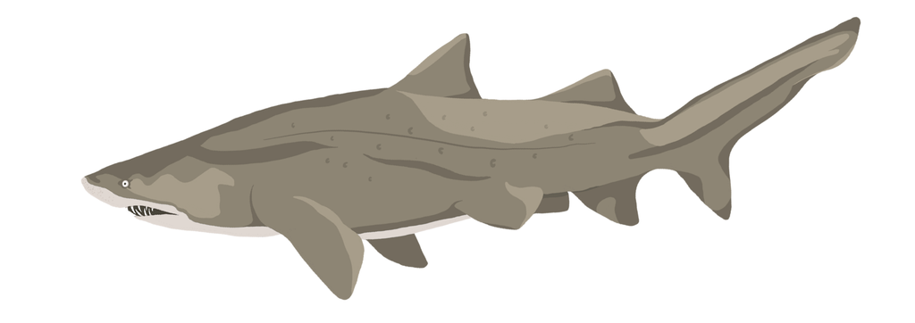

# What Makes a Home?

Environmental determinants of habitat use at Australia’s only known sand tiger shark (*Carcharias taurus*) gestation aggregation.

# About me

Hi! My name is Jarrod Cameron. I am a PhD candidate at the University of Sunshine Coast in the sunny state of Queensland, Australia. My research primarily concerns the environmental and climatic determinants of critical habitat selection for large elasmobranchs on Australia’s east coast. In plain speak, why do our sharks and rays use specific habitats for critical ecological functions like reproduction?

[figure not shown]

A pic from my last trip to Raja Ampat in 2024!

I have a particular focus on grey nurse sharks (*Carcharias taurus*) also known as sand tiger sharks, ragged tooth, mangoa, sardas, escalandrún, squalos toros, シロワニ (shirowani), and to the traditional custodians of our home- the Kabi Kabi people- girringii.

Grey nurse sharks are a large-bodied coastal shark known for taking large-scale migratory movements across our coastline. In Australia, grey nurse were subjected to intensive fishing pressure in the 1960’s and 70’s resulting in an estimated population decline of over 80%! Following this rapid population decline, game fishers voluntarily banned capture of the species in 1979 and the New South Wales (NSW) state government declared the species protected in 1984, making it the first shark in the world to be offered legislative protections. However, the grey nurse has been quite slow to recover on account of their extremely low reproductive output (one of the lowest of any shark species) producing at a maximum two pups every 2-3 years. Additionally, the species is quite slow growing only reaching sexual maturity at 8 years for males and 10 years for females.

[video not shown]

Figure 1: Pup moving inside a late term sand tiger shark (*C. taurus*) at Wolf Rock in Winter.

If you want to learn more about our research and how you can help, please read on! Otherwise, If you’re interested in getting in touch please reach out via email jarrod.cameron@research.usc.edu.au or social media [@FinsInFrame](https://www.instagram.com/finsinframe/) (Instagram and Github are best!).

# How you can help!

One of the ways we track our grey nurse population’s health is through a technique called photo-ID. Grey nurse have a collection of freckles unique to each individual, which we can photograph and identify the individual. These spots occur on the sides of the shark (see below), if you manage to get a photo you can upload the pictures to [spotashark.com](https://spotashark.com/) to help research!

Also, if the shark happens to be a new one, you get to name it!

You can also visit [spotashark.com](https://spotashark.com/how-to-photograph/) to learn what makes a great ID shot!

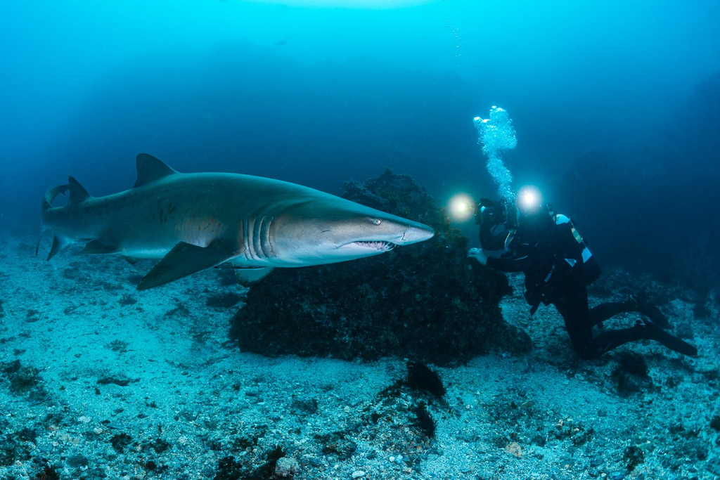

Figure 2: A pic of me doing photo-ID surveys at Flat Rock! Taken by my supervisor Simon J. Pierce.

# A bit more science speak about grey nurse and our recent project at Wolf Rock!

Grey nurse sharks on the east coast of Australia exhibiting strong reproductive philopatry with pregnant females spending the majority of their gestation at only one documented site in the entirety of Australia, Wolf Rock (Figure 3) (Bansemer and Bennett 2009, 2011; Dwyer et al. 2023). Wolf Rock is situated towards the warmest extent of the sharks range and is used exclusively by gestating females in the austral summer and autumn.

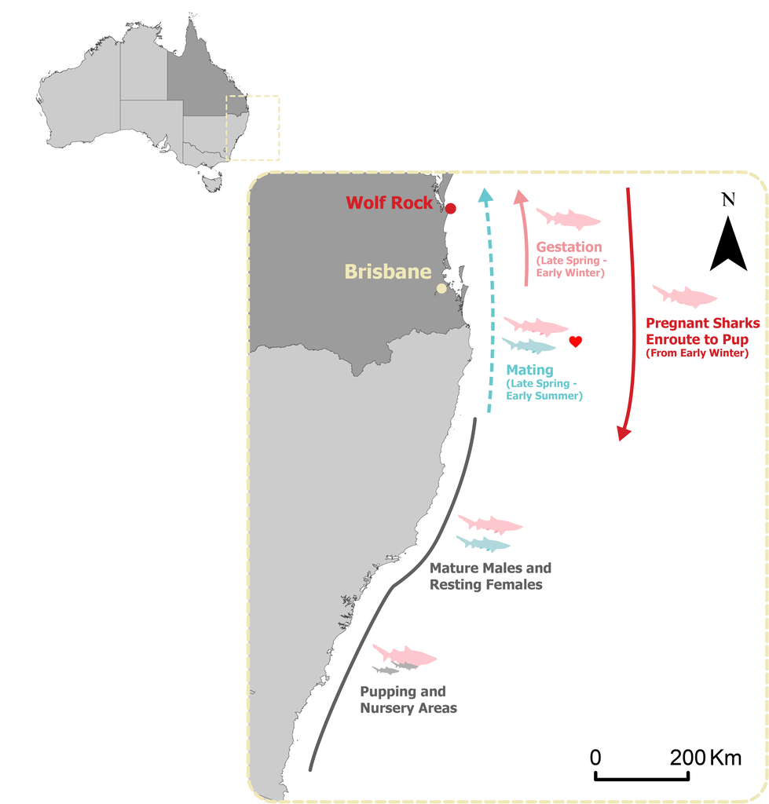

Figure 3: Biennial reproductive cycle of sand tiger sharks of the east coast of Australia. Females alternate between mating year-travelling to mate and gestate in northern waters-and resting year-remaining on the southern coast. Recreated from Bansemer and Bennett (2011).

However, very little is known about why these gestating females select this site. Using historical acoustic telemetry and satellite derived sea surface temperature (SST) we noticed a trend that females spend less time at the site during summer (particularly February) and decided to investigate the role of temperature on the number of days detected and the depth of the sharks.

# Study site

Wolf Rock (153°11.8’ E, 25°54.6’ S) is a popular dive site located on the east coast of Australia approximately 2km north north-east off the coast of Double Island Point, Queensland (Figure 4). The site consists of four rocky pinnacles aligned in a north-northeasterly direction and plenty of rocky rubble and gutters.

As mentioned, the site has global conservation importance as the only known gestation site for the critically endangered grey nurse shark in Australia. Additionally, Wolf Rock also boasts an incredible diversity of sharks and rays (over 20 species utilise the site in some capacity)! For this diversity and it’s importance to grey nurse, Wolf Rock is listed as an Important Shark and Ray Area (ISRA) by the IUCN SSG - check it out on the interactive [E-atlas here](https://sharkrayareas.org/e-atlas/).

[figure not shown]

Figure 4: Location of Wolf Rock off the coast of Double Island Point, Queensland, Australia, and a habitat classification map compiled from surveys conducted by Roelfsema et al. (2016).

We know from previous work that mating year females generally arrive in austral spring (from September), stay at the site through summer and depart south to pup early winter (from June) (Bansemer and Bennett 2009).

# Acoustic telemetry

## Historical data

There has been an ongoing acoustic monitoring effort at Wolf Rock since the early 2010’s. Acoustic telemetry arrays in varying complexities have been deployed at Wolf Rock to measure shark residence and movements at the site (Figure 5) (Dwyer et al. 2023).

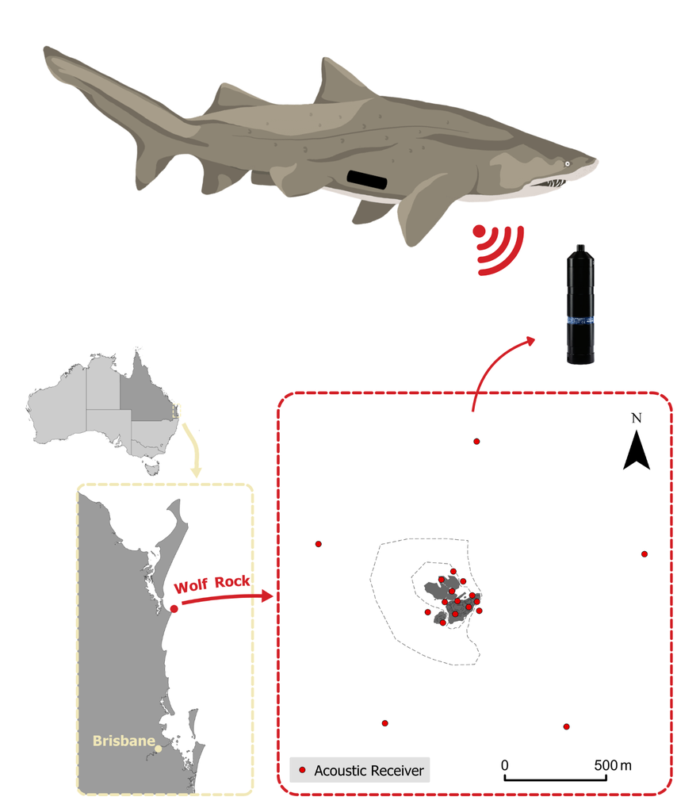

Figure 5: Acoustic telemetry stations at Wolf Rock over the last 16 years which pick up the presence of sharks equipped with acoustic transmitters.

Using the historic long-term acoustic monitoring program we can look at the number of days female sharks were detected in each month.

**Please note, graphs on this page are interactive and may be easier to handle if you turn your phone sideways!**

[interactive chart not shown]

Figure 6: Mean detection days of female sand tiger sharks per month at Wolf Rock from long-term IMOS acoustic monitoring (2010–2023). The pink line and points show the average detection days per shark per month, with the shaded ribbon representing one standard error. Hover over any point for monthly values.

Detection days drop sharply through summer, reaching a minimum in February — Wolf Rock’s hottest month. To better understand why this may be occurring we equipped 15 females (5 in 2024 and 10 in 2025) with temperature and pressure acoustic transmitters (Innovasea V16’s) to investigate the role of temperature and other environmental factors driving site selection and use.

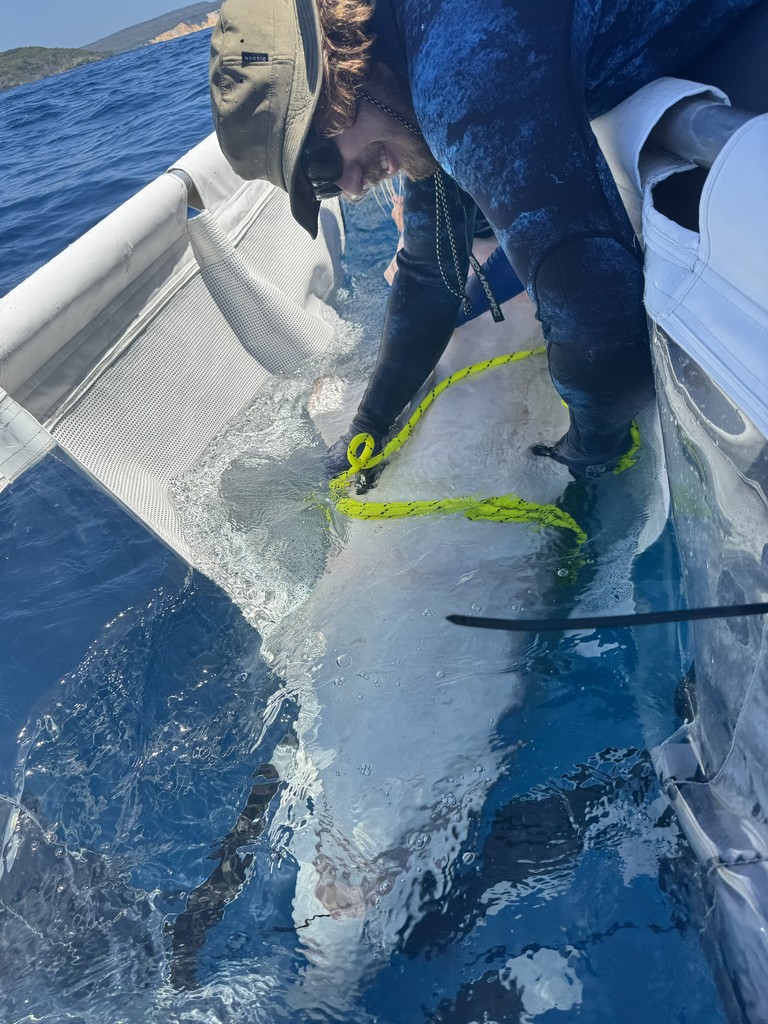

Tagging sand tigers at Wolf Rock in 2025.

## Females tagged in 2024

So far we only have the data for the five females tagged in 2024 and will collect the 2025 data in October of 2026. We extracted the temperature logged by acoustic receiver units to determine mean temperature at a depth of ~20 meters. We also supplemented this with satellite derived sea surface temperature accessed via the IMOS THREDDS server (https://mrs-data.csiro.au/) using the “remora” r package (Jaine et al. 2021).

[interactive chart not shown]

Figure 7: Mean monthly detection days per female sharks at Wolf Rock (left axis, pink) and three temperature series (right axis) for the 2024 cohort of tagged females: satellite-derived sea surface temperature (SST, red), in-situ receiver temperature (blue, dashed), and internal animal body temperature recorded from acoustic transmitters (grey, dotted). Click any series in the legend to toggle its visibility, and hover over any point for monthly values.

Both SST and receiver temperature (or temperature at depth) signals peak in summer alongside the trough in detection days. Additionally, temperatures seem to converge in February meaning that sharks can’t rely on deeper water at the site to stay cooler. However, detection days drop off and the sharks temperature stays *relatively* cool.

So where are they going? Do sharks go deeper when it is warmer?

## Depth and temperature in summer

[interactive chart not shown]

Figure 8: Relationship between mean daily receiver (ambient) temperature and the mean daily depth occupied by gestating females during austral summer. Each point represents one shark-day; the y-axis is reversed so depth increases downward, and point colour indicates the corresponding mean daily animal body temperature. The grey trend line is a linear fit with 95% confidence band.

# Summary and next steps

Together these patterns suggest that as Wolf Rock warms in summer, sharks both reduce their time at the receivers and shift deeper. Further analysis is needed to test whether this pattern holds statistical significance across years and individuals, and how the thermal habitat at Wolf Rock may shift under continued ocean warming. Some of these sharks also possessed MiniPAT satellite archival tags which is a can of worms I will be opening when I return home after the conference…

Stay tuned for the follow up paper!

# Thanks for reading!

If you made it to the end thanks for reading this brief quarto website I made (it was my first time coding one and I really enjoyed it)!

Thanks also go to my co-authors and supervisors who support me in this research and additional thanks to Simon for his wonderful photographs which always find their way into my presentations. I’m also very grateful to my friend Dr. Grace Smith who provided the illustration of the sand tiger shark used in this quarto and my presentation. If you’re interested in her art please check out her [Instagram @graceponders](https://www.instagram.com/graceponders/)!

#### Authors

**Jarrod Cameron**<sup>1</sup>, **Simon J. Pierce**<sup>1,2</sup>, **Christine L. Dudgeon**<sup>1,3</sup>, **Carley S. Kilpatrick**<sup>4</sup>, **Ross G. Dwyer**<sup>1</sup>

<sup>1</sup> School of Science, Technology and Engineering, The University of the Sunshine Coast, Sippy Downs, QLD, Australia. <sup>2</sup> Marine Megafauna Foundation, West Palm Beach, FL 33411, United States of America.  
<sup>3</sup> Biopixel Oceans Foundation, Fortitude Valley, Queensland 4006, Australia. <sup>4</sup> Queensland Parks and Wildlife Service and Partnerships, Department of Environment, Science and Innovation, Manly, Queensland 4179, Australia.

Correspondence: Jarrod.cameron@research.usc.edu.au · [@FinsInFrame](https://instagram.com/FinsInFrame)

# Bibliography

Bansemer, Carley S., and Mike B. Bennett. 2009. “Reproductive Periodicity, Localised Movements and Behavioural Segregation of Pregnant Carcharias Taurus at Wolf Rock, Southeast Queensland, Australia.” *Marine Ecology Progress Series* 374 (January): 215–27. https://doi.org/10.3354/meps07741.

Bansemer, Carley S., and Mike B. Bennett. 2011. “Sex- and Maturity-Based Differences in Movement and Migration Patterns of Grey Nurse Shark, Carcharias Taurus, Along the Eastern Coast of Australia.” *Mar. Freshwater Res.* 62 (6): 596–606. https://doi.org/10.1071/MF10152.

Dwyer, Ross G., Michaela Rathbone, Deborah L. Foote, et al. 2023. “Marine Reserve Use by a Migratory Coastal Shark, Carcharias Taurus.” *Biological Conservation* 283 (July): 110099. https://doi.org/10.1016/j.biocon.2023.110099.

Jaine, Fabrice, Ian D. Jonsen, Vinay Udyawer, et al. 2021. *Remora: Rapid Extraction of Marine Observations for Roving Animals*.

Roelfsema, Christiaan M, Carley Bansemer, Kathryn M McMahon, and Karen Joyce. 2016. *2003 Habitat Maps Derived from Grey Nurse Shark (GNS) Project of Wolf Rock, Double Island Point, Queensland, Australia*. PANGAEA. https://doi.org/10.1594/PANGAEA.864211.